# Data 607, Project 2

Tyler Graham

2025-03-09

## Data 607 - Project 2

To begin, here is a summary of the tasks I’ll be completing for this project:

Project 2 - Data 607: Summary of Tasks

Dataset Selection:

Choose any three “wide” datasets from the Week 6 Discussion items. Avoid using the Sample Post dataset (already used in Week 6).

Data Preparation:

For each chosen dataset, create a CSV file (or optionally a MySQL database) that contains all the dataset information. Use a “wide” structure that mirrors how the data appears in the discussion item.

Data Import & Transformation:

Read each CSV file into R. Use the tidyr and dplyr packages to tidy and transform your data. (Note: This step carries the most weight in your grade.)

Analysis & Documentation:

Perform the analysis as requested in the discussion item for each dataset. Prepare an R Markdown file that includes your code, narrative descriptions of your data cleanup, analysis, and conclusions. Publish the R Markdown file to rpubs.com.

```r
library(dplyr)
library(tidyverse)
```

With the correct packages installed, it’s time to bring in the Data. I will be using:

D&D Data I shared in Discussion Cheeses Data shared by a classmate Rolling Stone Top Album data shared by a classmate.

I downloaded all the datasets in their untidy forms and loaded them into my Github for easy access. Time to pull the untidy data into this project and check that it loaded in properly:

```r
DungeonsAndDragons <- "https://raw.githubusercontent.com/tcgraham-data/Data-607-Project-2/refs/heads/main/dnd_chars_all.csv"
Cheese <- "https://raw.githubusercontent.com/tcgraham-data/Data-607-Project-2/refs/heads/main/cheeses.csv"
ROllingStoneTopAlbums <- "https://raw.githubusercontent.com/tcgraham-data/Data-607-Project-2/refs/heads/main/Rolling%20Stone%20500%20(public)%20-%20Data.csv"

dnddata <- read.csv(DungeonsAndDragons)
cheesedata <- read.csv(Cheese)
albumdata <- read.csv(ROllingStoneTopAlbums)

head(dnddata)
```

```
##        ip  finger                             hash     name           race
## 1         ed15f9d fe3ed6570067d2cd808bcee0a4396824 ee1e382c     Hill Dwarf
## 2         ed15f9d aa656cef94740b1da714d82782d8a8c4 ee1e382c     Hill Dwarf
## 3 6b5d3f4 d922658 04b9abba9ce759ef13319c520bf0eb69 f1f6ff43          Human
## 4 9b7218f b5d19a0 ba92372c716a832e03e866447cb2d102 f92bdd74 Fallen Aasimar
## 5 9b7218f b5d19a0 2f4a637dd42b9aa945abf870fe34edcf f92bdd74 Fallen Aasimar
## 6 bf0845c 6594cbd de16fbfebad327876582875339ad1e1f 5b8cf3ca        Variant
##               background                 date                class
## 1 Guild Member - Justice 2022-08-23T20:02:11Z Sorcerer 13|Cleric 1
## 2 Guild Member - Justice 2022-08-23T19:43:25Z Sorcerer 13|Cleric 1
## 3                  Noble 2022-08-22T14:57:09Z           Fighter 13
## 4              Outlander 2022-08-22T12:12:53Z   Sorcerer 3|Druid 2
## 5              Outlander 2022-08-22T12:07:21Z   Sorcerer 3|Druid 2
## 6            Entertainer 2022-08-22T03:19:30Z               Bard 1
##         justClass                        subclass level
```

[output cut: 69 more lines]

```r
head(cheesedata)
```

```
##               cheese                                        url  milk
## 1         Aarewasser         https://www.cheese.com/aarewasser/   cow
## 2   Abbaye de Belloc   https://www.cheese.com/abbaye-de-belloc/ sheep
## 3   Abbaye de Belval   https://www.cheese.com/abbaye-de-belval/   cow
## 4  Abbaye de Citeaux  https://www.cheese.com/abbaye-de-citeaux/   cow
## 5    Abbaye de Tamié              https://www.cheese.com/tamie/   cow
## 6 Abbaye de Timadeuc https://www.cheese.com/abbaye-de-timadeuc/   cow
##       country               region family                       type
## 1 Switzerland                 <NA>   <NA>                  semi-soft
## 2      France          Pays Basque   <NA>         semi-hard, artisan
## 3      France                 <NA>   <NA>                  semi-hard
## 4      France             Burgundy   <NA> semi-soft, artisan, brined
## 5      France               Savoie   <NA>              soft, artisan
## 6      France province of Brittany   <NA>                  semi-hard
##   fat_content calcium_content               texture    rind       color
```

[output cut: 27 more lines]

```r
head(albumdata)
```

```
##        Sort.Name     Clean.Name                      Album X2003.Rank.Old
## 1 Sinatra, Frank  Frank Sinatra     In the Wee Small Hours            101
## 2    Diddley, Bo     Bo Diddley Bo Diddley / Go Bo Diddley            212
## 3 Presley, Elvis  Elvis Presley              Elvis Presley             56
## 4 Sinatra, Frank  Frank Sinatra Songs for Swingin' Lovers!            302
## 5 Little Richard Little Richard      Here's Little Richard             50
## 6        Beyonce        Beyonce                   Lemonade             NA
##   X2003.Rank X2012.Rank X2020.Rank X2020.2003.Differential Release.Year
## 1        100        101        282                    -182         1955
## 2        214        216        455                    -241         1955
## 3         55         56        332                    -277         1956
## 4        306        308         NA                    -195         1956
## 5         50         50        227                    -177         1957
## 6         NA         NA         32                     469         2016
##                   Album.Genre Album.Type Wks.on.Billboard
```

[output cut: 48 more lines]

Now that our data is loaded, we need to clean it up with the intent of doing something with it. Since a lot of the discussions didn’t necessarily have a request built in, I have developed my own questions to answer:

## Dungeons And Dragons Data

First thing we need to do is remove columns that aren’t providing us with any real data related to the game itself. This can be done by manually look at the columns and striking those which aren’t relevant using dplyr:

```r
dnd_data_clean <- dnddata %>%
  select(-matches("^(name|ip|finger|hash|date|alias)"))

head(dnd_data_clean)
```

```
##             race             background                class       justClass
## 1     Hill Dwarf Guild Member - Justice Sorcerer 13|Cleric 1 Sorcerer|Cleric
## 2     Hill Dwarf Guild Member - Justice Sorcerer 13|Cleric 1 Sorcerer|Cleric
## 3          Human                  Noble           Fighter 13         Fighter
## 4 Fallen Aasimar              Outlander   Sorcerer 3|Druid 2  Sorcerer|Druid
## 5 Fallen Aasimar              Outlander   Sorcerer 3|Druid 2  Sorcerer|Druid
## 6        Variant            Entertainer               Bard 1            Bard
##                          subclass level                                  feats
## 1     Clockwork Soul|Order Domain    14 Fey Touched|War Caster|Metamagic Adept
## 2     Clockwork Soul|Order Domain    14
## 3                 Eldritch Knight    13                     Heavy Armor Master
## 4 Shadow Magic|Circle of Wildfire     5
## 5 Shadow Magic|Circle of Wildfire     5
## 6                                     1
##    HP AC Str Dex Con Int Wis Cha      alignment
```

[output cut: 62 more lines]

With that done, we need to get an “NA” added to any cell that is currently empty. That way I don’t have to worry about cells getting weird on me:

```r
dnd_data_clean <- dnd_data_clean %>%
  mutate(across(where(is.character), ~na_if(., "")))

head(dnd_data_clean)
```

```
##             race             background                class       justClass
## 1     Hill Dwarf Guild Member - Justice Sorcerer 13|Cleric 1 Sorcerer|Cleric
## 2     Hill Dwarf Guild Member - Justice Sorcerer 13|Cleric 1 Sorcerer|Cleric
## 3          Human                  Noble           Fighter 13         Fighter
## 4 Fallen Aasimar              Outlander   Sorcerer 3|Druid 2  Sorcerer|Druid
## 5 Fallen Aasimar              Outlander   Sorcerer 3|Druid 2  Sorcerer|Druid
## 6        Variant            Entertainer               Bard 1            Bard
##                          subclass level                                  feats
## 1     Clockwork Soul|Order Domain    14 Fey Touched|War Caster|Metamagic Adept
## 2     Clockwork Soul|Order Domain    14                                   <NA>
## 3                 Eldritch Knight    13                     Heavy Armor Master
## 4 Shadow Magic|Circle of Wildfire     5                                   <NA>
## 5 Shadow Magic|Circle of Wildfire     5                                   <NA>
## 6                            <NA>     1                                   <NA>
##    HP AC Str Dex Con Int Wis Cha      alignment
```

[output cut: 62 more lines]

Since I’m really only interested in the “race” and “justClass” columns for my observation, I want to make sure we remove any rows where those are empty. Since you can’t functionally play the game without those two elements, there’s not really a reason to measure them, even as “empty”:

```r
dnd_data_clean <- dnd_data_clean %>%
  filter(!is.na(race) & race != "empty",
         !is.na(justClass) & justClass != "empty")

# Display the cleaned dataset
head(dnd_data_clean)
```

```
##             race             background                class       justClass
## 1     Hill Dwarf Guild Member - Justice Sorcerer 13|Cleric 1 Sorcerer|Cleric
## 2     Hill Dwarf Guild Member - Justice Sorcerer 13|Cleric 1 Sorcerer|Cleric
## 3          Human                  Noble           Fighter 13         Fighter
## 4 Fallen Aasimar              Outlander   Sorcerer 3|Druid 2  Sorcerer|Druid
## 5 Fallen Aasimar              Outlander   Sorcerer 3|Druid 2  Sorcerer|Druid
## 6        Variant            Entertainer               Bard 1            Bard
##                          subclass level                                  feats
## 1     Clockwork Soul|Order Domain    14 Fey Touched|War Caster|Metamagic Adept
## 2     Clockwork Soul|Order Domain    14                                   <NA>
## 3                 Eldritch Knight    13                     Heavy Armor Master
## 4 Shadow Magic|Circle of Wildfire     5                                   <NA>
## 5 Shadow Magic|Circle of Wildfire     5                                   <NA>
## 6                            <NA>     1                                   <NA>
##    HP AC Str Dex Con Int Wis Cha      alignment
```

[output cut: 62 more lines]

I do want to make it clear I want to keep all this data because you never know when you might need it. You never know when you just NEED to know what percentage of DnD players are Eldritch Knights…But since I’m not going to use all of it, I want to make a unique datafram with only the information I’m interested in:

```r
dnd_subset <- dnd_data_clean %>% select(race, justClass)

head(dnd_subset)
```

```
##             race       justClass
## 1     Hill Dwarf Sorcerer|Cleric
## 2     Hill Dwarf Sorcerer|Cleric
## 3          Human         Fighter
## 4 Fallen Aasimar  Sorcerer|Druid
## 5 Fallen Aasimar  Sorcerer|Druid
## 6        Variant            Bard
```

Now we’re getting somewhere. The last thing I see that’s a problem is that some characters have dual-classed. How do I treat that? In DnD parlance, the first listed class is the primary class, and the second is a secondary classing. Now we’ll want to make a new column that splits up any dual classes by looking for a pipe and extracting info after the pipe:

```r
dnd_subset <- dnd_subset %>%
  mutate(`Secondary Class` = ifelse(grepl("\\|", justClass),
                                      sub(".*\\|", "", justClass),
                                      NA))

head(dnd_subset)
```

```
##             race       justClass Secondary Class
## 1     Hill Dwarf Sorcerer|Cleric          Cleric
## 2     Hill Dwarf Sorcerer|Cleric          Cleric
## 3          Human         Fighter            <NA>
## 4 Fallen Aasimar  Sorcerer|Druid           Druid
## 5 Fallen Aasimar  Sorcerer|Druid           Druid
## 6        Variant            Bard            <NA>
```

That bit of research worked well. But I still have the extra secondary data in justClass and need to remove it. And I want to rename “justClass” to “Primary Class”

```r
dnd_subset <- dnd_subset %>%
  mutate(justClass = sub("\\|.*", "", justClass)) %>%
  rename(`Primary Class` = justClass)
head(dnd_subset)
```

```
##             race Primary Class Secondary Class
## 1     Hill Dwarf      Sorcerer          Cleric
## 2     Hill Dwarf      Sorcerer          Cleric
## 3          Human       Fighter            <NA>
## 4 Fallen Aasimar      Sorcerer           Druid
## 5 Fallen Aasimar      Sorcerer           Druid
## 6        Variant          Bard            <NA>
```

And to just clean this up a little bit more, so we can capture who does and doesn’t have a Second class:

```r
dnd_subset <- dnd_subset %>%
  mutate(`Secondary Class` = ifelse(is.na(`Secondary Class`) | `Secondary Class` == "", "none", `Secondary Class`))
head(dnd_subset)
```

```
##             race Primary Class Secondary Class
## 1     Hill Dwarf      Sorcerer          Cleric
## 2     Hill Dwarf      Sorcerer          Cleric
## 3          Human       Fighter            none
## 4 Fallen Aasimar      Sorcerer           Druid
## 5 Fallen Aasimar      Sorcerer           Druid
## 6        Variant          Bard            none
```

##DnD Question 1 - What’s the most popular race?

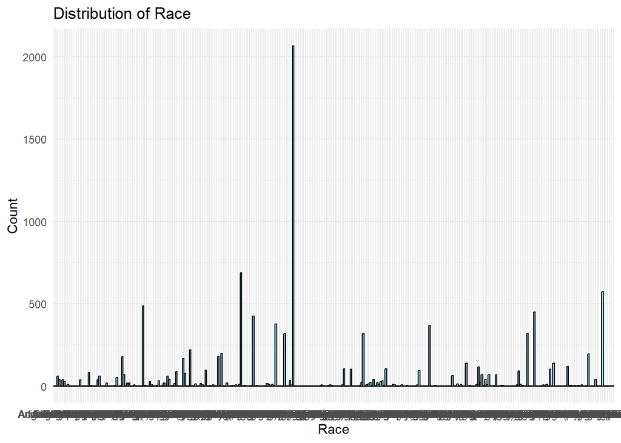

```r
library(ggplot2)

ggplot(dnd_subset, aes(x = race)) +
  geom_bar(fill = "skyblue", color = "black") +
  labs(title = "Distribution of Race", x = "Race", y = "Count") +
  theme_minimal()
```

That was unhelpful. I had no idea there were that many race options in the game. Color me impressed. I guess we’ll just tabulate this differently. Let’s make a new dataset that lists all races and then counts each instance and descends from most to least. Then we can graph the top ten.

```r
dnd_race_count <- dnd_subset %>%
  count(race) %>%
  rename(Count = n) %>%
  arrange(desc(Count))

print(dnd_race_count)
```

```
##                                   race Count
## 1                                Human  2068
## 2                             Half-Elf   688
## 3                             Wood Elf   572
## 4                           Dragonborn   486
## 5                             Tiefling   449
## 6                             Half-Orc   425
## 7                             High Elf   378
## 8                       Mountain Dwarf   368
## 9                               Tabaxi   320
## 10                          Hill Dwarf   319
## 11                  Lightfoot Halfling   318
## 12                        Forest Gnome   219
## 13                             Goliath   198
## 14                           Warforged   194
```

[output cut: 307 more lines]

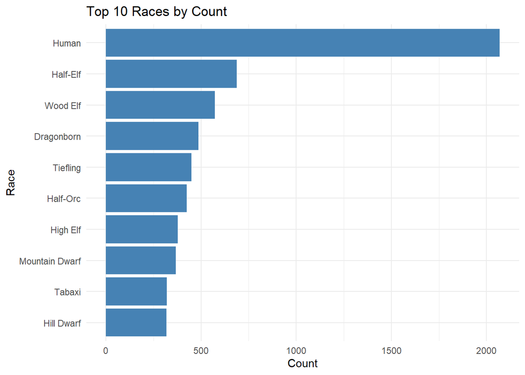

```r
library(ggplot2)

top_races <- dnd_race_count %>%
  slice_max(Count, n = 10)

ggplot(top_races, aes(x = reorder(race, Count), y = Count)) +
  geom_bar(stat = "identity", fill = "steelblue") +
  coord_flip() +
  labs(title = "Top 10 Races by Count", x = "Race", y = "Count") +
  theme_minimal()
```

This is cool. And it makes a lot of sense. In the game, humans get +1 to all stats for a total of +6 overall. Other races have a total of +3 to a stat. The “upside” to choosing a race other than human is that while humans have a blanket +1 to every stat, each race has one stat that receives a +2 perk. In general, this makes humans easier to play for new players. Most new players are encouraged to start with a human and then choose a more interesting race on the “next” game. I wonder what the percentage is between “human” and “all others:

```r
human_vs_other <- dnd_race_count %>%
  mutate(race_group = ifelse(tolower(race) == "human", "Human", "Other")) %>%
  group_by(race_group) %>%
  summarise(Total_Count = sum(Count))

human_vs_other
```

```
## # A tibble: 2 × 2
##   race_group Total_Count
##   <chr>            <int>
## 1 Human             2068
## 2 Other             8808
```

```r
total_count <- sum(human_vs_other$Total_Count)

human_count <- human_vs_other %>%
  filter(race_group == "Human") %>%
  pull(Total_Count)

human_percentage <- (human_count / total_count) * 100

human_percentage
```

```
## [1] 19.01434
```

That’s much more in line with what I thought. The bar chart makes it look like Humans are far and away the top choice. Which they are for a single racial class. However, the reality is that it’s going to be the largest instance because it is the most friendly to beginner players. So it’s almost better to think of “human” as beginners and all others as veteran players. I would believe that 81% of DnD players more likely to play more complex and challenging characters.

## D&D Data Question 2 - What’s the most played character class?

```r
dnd_class_count <- dnd_subset %>%
  count(`Primary Class`) %>%
  rename(Count = n) %>%
  arrange(desc(Count))

dnd_class_count
```

```
##        Primary Class Count
## 1            Fighter  1463
## 2              Rogue  1308
## 3             Cleric  1003
## 4          Barbarian   956
## 5            Paladin   891
## 6             Ranger   749
## 7             Wizard   747
## 8              Druid   722
## 9               Monk   716
## 10              Bard   701
## 11          Sorcerer   658
## 12           Warlock   649
## 13         Artificer   218
## 14    Revised Ranger    44
## 15      Blood Hunter    26
## 16            Mystic    13
## 17             Dwarf     2
## 18        Gunslinger     2
## 19          Half-Elf     2
## 20      Battle Clown     1
## 21 Crafting Commoner     1
## 22        Dragonborn     1
## 23            Genasi     1
## 24             Human     1
## 25          commoner     1
```

```r
top_classes <- dnd_class_count %>%
  slice_max(Count, n = 10)

top_classes
```

```
##    Primary Class Count
## 1        Fighter  1463
## 2          Rogue  1308
## 3         Cleric  1003
## 4      Barbarian   956
## 5        Paladin   891
## 6         Ranger   749
## 7         Wizard   747
## 8          Druid   722
## 9           Monk   716
## 10          Bard   701
```

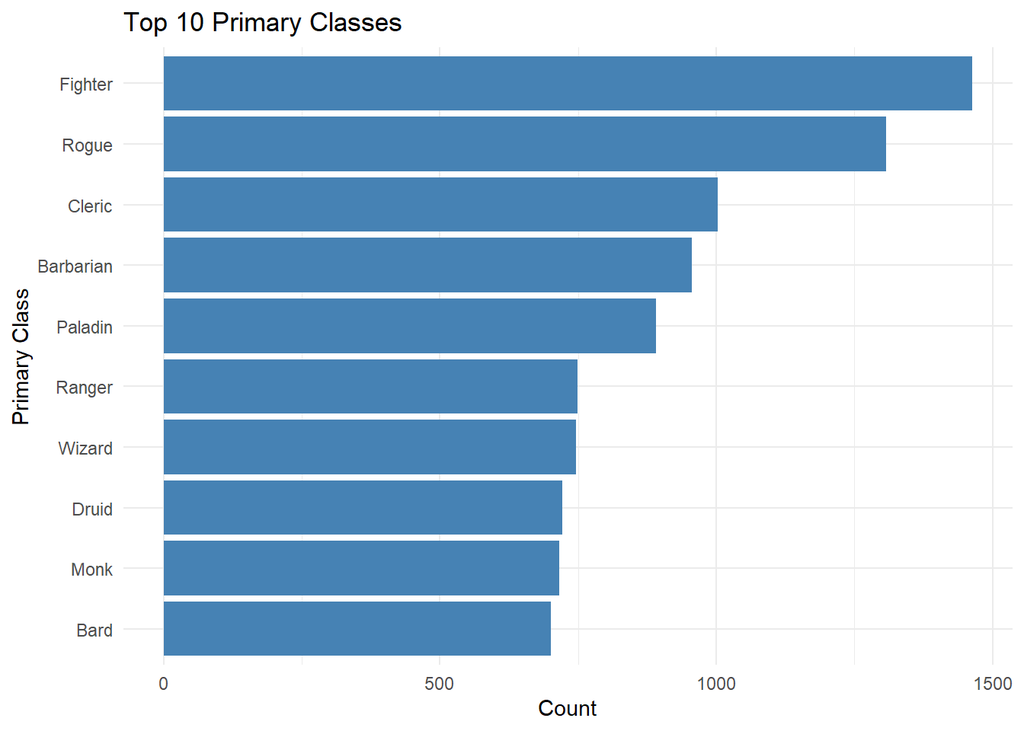

```r
ggplot(top_classes, aes(x = reorder(`Primary Class`, Count), y = Count)) +
  geom_bar(stat = "identity", fill = "steelblue") +
  coord_flip() +
  labs(title = "Top 10 Primary Classes", x = "Primary Class", y = "Count") +
  theme_minimal()
```

Answer: Fighter. That makes a lot of sense. It’s one of the most flexible classes to generally do what you want to do. About all you can’t do well as a “fighter” is cast magic. But magic users are hard because they get real squishy, real fast. OK. I’ve spent way too much time on DnD data. Time to tackle CHeese.

## Cheese Data

OK. I have to get more focused on what I’m doing here. I don’t want this to ramble too much. My main question here was:

## Which nation makes the most chesses on earth?

Let’s begin be tidying up our data. There are a few columns here that don’t provide us with much information, nor do we really need it because of how little infor we get out of it. So let’s scrub some data:

```r
cheese_data_clean <- cheesedata %>%
  select(-matches("^(url|region|family|fat_content|calcium_content|synonyms|alt_spellings|producers|vegetarian|vegan)"))

head(cheese_data_clean)
```

```
##               cheese  milk     country                       type
## 1         Aarewasser   cow Switzerland                  semi-soft
## 2   Abbaye de Belloc sheep      France         semi-hard, artisan
## 3   Abbaye de Belval   cow      France                  semi-hard
## 4  Abbaye de Citeaux   cow      France semi-soft, artisan, brined
## 5    Abbaye de Tamié   cow      France              soft, artisan
## 6 Abbaye de Timadeuc   cow      France                  semi-hard
##                 texture    rind       color                flavor
## 1               buttery  washed      yellow                 sweet
## 2   creamy, dense, firm natural      yellow         burnt caramel
## 3               elastic  washed       ivory                  <NA>
## 4 creamy, dense, smooth  washed       white acidic, milky, smooth
## 5  creamy, open, smooth  washed       white         fruity, nutty
## 6                  soft  washed pale yellow         salty, smooth
##               aroma
## 1           buttery
## 2          lanoline
## 3          aromatic
## 4 barnyardy, earthy
## 5 perfumed, pungent
## 6             nutty
```

Now we need to update this so that any empty cells are given the null of “NA”

```r
cheese_data_clean <- cheese_data_clean %>%
  mutate(across(where(is.character), ~na_if(., "")))

head(cheese_data_clean)
```

```
##               cheese  milk     country                       type
## 1         Aarewasser   cow Switzerland                  semi-soft
## 2   Abbaye de Belloc sheep      France         semi-hard, artisan
## 3   Abbaye de Belval   cow      France                  semi-hard
## 4  Abbaye de Citeaux   cow      France semi-soft, artisan, brined
## 5    Abbaye de Tamié   cow      France              soft, artisan
## 6 Abbaye de Timadeuc   cow      France                  semi-hard
##                 texture    rind       color                flavor
## 1               buttery  washed      yellow                 sweet
## 2   creamy, dense, firm natural      yellow         burnt caramel
## 3               elastic  washed       ivory                  <NA>
## 4 creamy, dense, smooth  washed       white acidic, milky, smooth
## 5  creamy, open, smooth  washed       white         fruity, nutty
## 6                  soft  washed pale yellow         salty, smooth
##               aroma
## 1           buttery
## 2          lanoline
## 3          aromatic
## 4 barnyardy, earthy
## 5 perfumed, pungent
## 6             nutty
```

Perfect. Now we have solid data. But it’s still wide and we need to make it long to get the answer we seek. And I need to make the question harder so I can have fun exploding columns. Let’s keep cheese, country, and type:

```r
cheese_data_subset <- cheese_data_clean %>%
  select(cheese, country, type)


head(cheese_data_subset)
```

```
##               cheese     country                       type
## 1         Aarewasser Switzerland                  semi-soft
## 2   Abbaye de Belloc      France         semi-hard, artisan
## 3   Abbaye de Belval      France                  semi-hard
## 4  Abbaye de Citeaux      France semi-soft, artisan, brined
## 5    Abbaye de Tamié      France              soft, artisan
## 6 Abbaye de Timadeuc      France                  semi-hard
```

Great. Now I want to generate new columns for type such that each column only has one descriptor:

```r
cheese_data_subset <- cheese_data_subset %>%
  mutate(type = trimws(type)) %>%
  separate(type, into = c("type1", "type2", "type3"), sep = ",", fill = "right", extra = "drop")

head(cheese_data_subset)
```

```
##               cheese     country     type1    type2   type3
## 1         Aarewasser Switzerland semi-soft     <NA>    <NA>
## 2   Abbaye de Belloc      France semi-hard  artisan    <NA>
## 3   Abbaye de Belval      France semi-hard     <NA>    <NA>
## 4  Abbaye de Citeaux      France semi-soft  artisan  brined
## 5    Abbaye de Tamié      France      soft  artisan    <NA>
## 6 Abbaye de Timadeuc      France semi-hard     <NA>    <NA>
```

OK this is getting fun. type1 really seams to be about cheese hardness. So let’s rename the columns and then sort data accordingly:

```r
cheese_data_subset <- cheese_data_subset %>%
  rename(hardness = type1,
         category = type2,
         type = type3)

head(cheese_data_subset)
```

```
##               cheese     country  hardness category    type
## 1         Aarewasser Switzerland semi-soft     <NA>    <NA>
## 2   Abbaye de Belloc      France semi-hard  artisan    <NA>
## 3   Abbaye de Belval      France semi-hard     <NA>    <NA>
## 4  Abbaye de Citeaux      France semi-soft  artisan  brined
## 5    Abbaye de Tamié      France      soft  artisan    <NA>
## 6 Abbaye de Timadeuc      France semi-hard     <NA>    <NA>
```

```r
unique_hardness <- unique(cheese_data_subset$hardness)
unique_category <- unique(cheese_data_subset$category)
unique_type <- unique(cheese_data_subset$type)

cat("Unique Hardness values:\n")
```

```
## Unique Hardness values:
```

```r
print(unique_hardness)
```

```
##  [1] "semi-soft"  "semi-hard"  "soft"       "hard"       "firm"
##  [6] "fresh soft" "semi-firm"  NA           "fresh firm" "artisan"
```

```r
cat("\nUnique Category values:\n")
```

```
##
## Unique Category values:
```

```r
print(unique_category)
```

```
##  [1] NA               " artisan"       " soft-ripened"  " brined"
##  [5] " blue-veined"   " smear-ripened" " semi-soft"     " processed"
##  [9] " firm"          " hard"          " whey"          " semi-hard"
## [13] " organic"
```

```r
cat("\nUnique Type values:\n")
```

```
##
## Unique Type values:
```

```r
print(unique_type)
```

```
## [1] NA               " brined"        " organic"       " blue-veined"
## [5] " artisan"       " soft-ripened"  " processed"     " smear-ripened"
```

Now we need to start moving data around to be in the correct columns.

```r
cheese_data_subset <- cheese_data_subset %>%
  mutate(
    category = if_else(
      hardness == "artisan",
      if_else(category %in% c("empty", "", NA_character_),
              "artisan",
              paste(category, "artisan", sep = ", ")),
      category
    ),
    hardness = if_else(hardness == "artisan", NA_character_, hardness)
  )

head(cheese_data_subset)
```

```
##               cheese     country  hardness category    type
## 1         Aarewasser Switzerland semi-soft     <NA>    <NA>
## 2   Abbaye de Belloc      France semi-hard  artisan    <NA>
## 3   Abbaye de Belval      France semi-hard     <NA>    <NA>
## 4  Abbaye de Citeaux      France semi-soft  artisan  brined
## 5    Abbaye de Tamié      France      soft  artisan    <NA>
## 6 Abbaye de Timadeuc      France semi-hard     <NA>    <NA>
```

Ok this worked so well that I decided I wanted to scan all three columns for all keywords. Then I wanted to seperate each key word into the right column. I thought this would be easy. It was not. I turned to the internet for help and discovered some new libraries to get this done. I don’t know if this is OK or not…but it tidies my data how I wanted it. So I guess there’s that.

```r
library(stringr)
library(purrr)

hardness_keywords <- c("semi-soft", "semi-hard", "soft", "hard", "firm", "fresh soft", "semi-firm", "fresh firm")
category_keywords <- c("artisan", "processed", "organic", "smear-ripened")
type_keywords     <- c("soft-ripened", "brined", "blue-veined", "smear-ripened", "whey")

reassign_keywords <- function(hardness_val, category_val, type_val) {
  all_vals <- c(hardness_val, category_val, type_val)
  all_vals <- unlist(str_split(all_vals, ","))
  all_vals <- str_trim(all_vals)
  all_vals <- all_vals[all_vals != ""]

  new_hardness <- paste(intersect(all_vals, hardness_keywords), collapse = ", ")
  new_category <- paste(intersect(all_vals, category_keywords), collapse = ", ")
  new_type     <- paste(intersect(all_vals, type_keywords), collapse = ", ")

  tibble(new_hardness = new_hardness,
         new_category = new_category,
         new_type = new_type)
}

new_values <- cheese_data_subset %>%
  select(hardness, category, type) %>%
  pmap_dfr(reassign_keywords)

cheese_data_subset_updated <- cheese_data_subset %>%
  bind_cols(new_values) %>%
  select(-hardness, -category, -type) %>%
  rename(
    hardness = new_hardness,
    category = new_category,
    type = new_type
  )

cheese_data_subset_updated <- cheese_data_subset_updated %>%
  mutate(across(everything(), ~ifelse(. == "", NA_character_, .)))

head(cheese_data_subset_updated)
```

```
##               cheese     country  hardness category   type
## 1         Aarewasser Switzerland semi-soft     <NA>   <NA>
## 2   Abbaye de Belloc      France semi-hard  artisan   <NA>
## 3   Abbaye de Belval      France semi-hard     <NA>   <NA>
## 4  Abbaye de Citeaux      France semi-soft  artisan brined
## 5    Abbaye de Tamié      France      soft  artisan   <NA>
## 6 Abbaye de Timadeuc      France semi-hard     <NA>   <NA>
```

PERFECT. This is the coolest thing I’ve done in R. I’m really happy with this. OK. Now to get a bar chart of cheeses by country of origin:

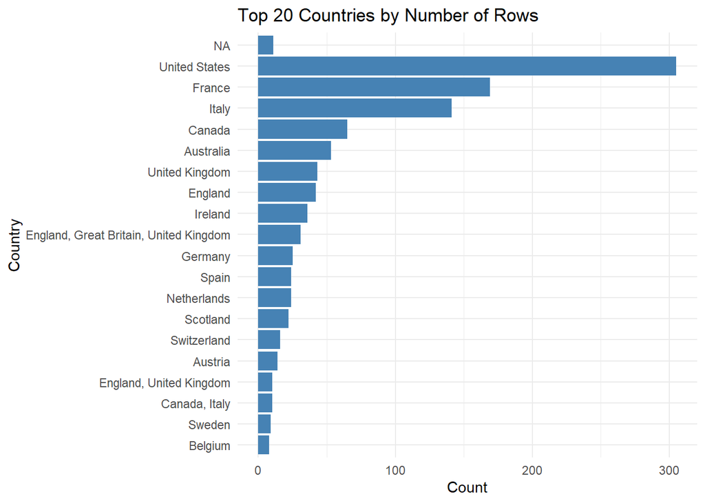

```r
country_counts <- cheese_data_subset_updated %>%
  count(country) %>%
  arrange(desc(n)) %>%
  slice_max(n, n = 20)

ggplot(country_counts, aes(x = reorder(country, n), y = n)) +
  geom_bar(stat = "identity", fill = "steelblue") +
  coord_flip() +
  labs(title = "Top 20 Countries by Number of Rows",
       x = "Country",
       y = "Count") +
  theme_minimal()
```

Oh crud. Turns our the country column was also comma dilineated. Let’s truncate that and redo the graph:

```r
cheese_data_subset_updated <- cheese_data_subset_updated %>%
  mutate(country = sub(",.*", "", country))

head(cheese_data_subset_updated$country)
```

```
## [1] "Switzerland" "France"      "France"      "France"      "France"
## [6] "France"
```

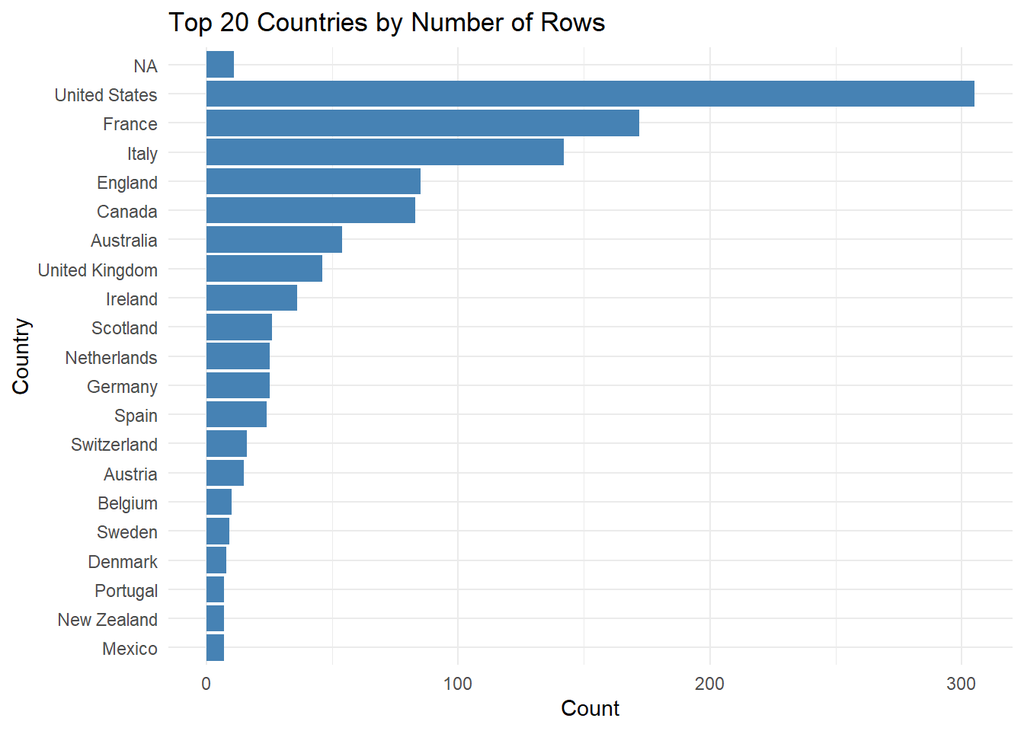

```r
country_counts <- cheese_data_subset_updated %>%
  count(country) %>%
  arrange(desc(n)) %>%
  slice_max(n, n = 20)


ggplot(country_counts, aes(x = reorder(country, n), y = n)) +
  geom_bar(stat = "identity", fill = "steelblue") +
  coord_flip() +
  labs(title = "Top 20 Countries by Number of Rows",
       x = "Country",
       y = "Count") +
  theme_minimal()
```

Better. I suppose if I’m being thorough. I should collapse “Ireland” “Scotland” and “England” all into “United Kingdom” and see how it looks. It’ll have an effect…

```r
cheese_data_subset_updated <- cheese_data_subset_updated %>%
  mutate(country = case_when(
    country %in% c("Ireland", "Scotland", "England") ~ "United Kingdom",
    TRUE ~ country
  ))

head(cheese_data_subset_updated$country)
```

```
## [1] "Switzerland" "France"      "France"      "France"      "France"
## [6] "France"
```

Let’s try the chart one more time:

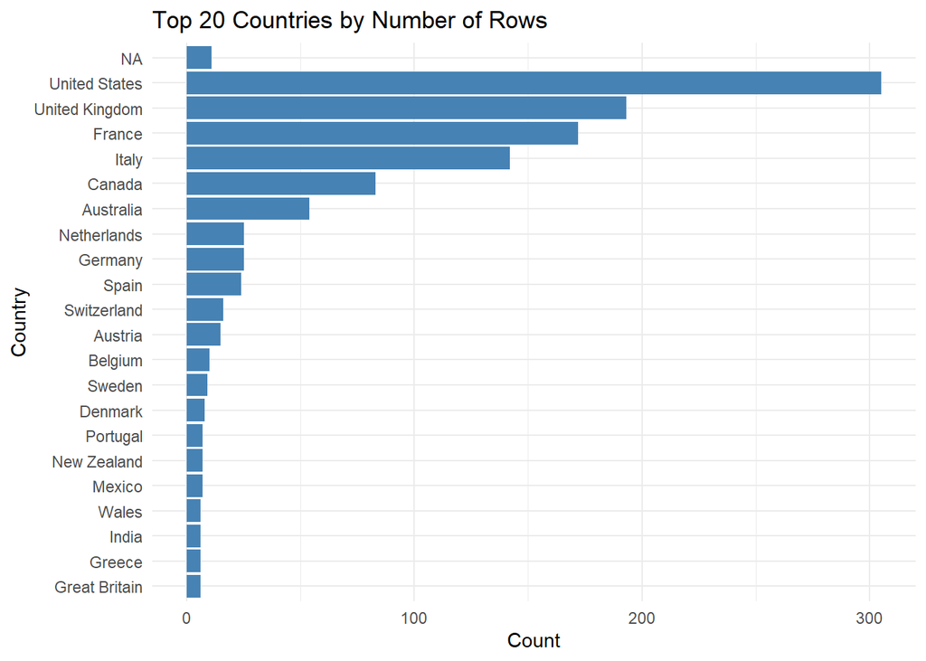

```r
country_counts <- cheese_data_subset_updated %>%
  count(country) %>%
  arrange(desc(n)) %>%
  slice_max(n, n = 20)

ggplot(country_counts, aes(x = reorder(country, n), y = n)) +
  geom_bar(stat = "identity", fill = "steelblue") +
  coord_flip() +
  labs(title = "Top 20 Countries by Number of Rows",
       x = "Country",
       y = "Count") +
  theme_minimal()
```

Who in the world makes the most cheese? The United States. King of Cheese.

Onto the last bit of data.

##Rolling Stone Top Album Data

I am refusing to go off on any wild data goose chases. I’m like 5 hours into this project and ready to wrap it up. So here’s the question we want to answer, knowing that we have the top album data from 2003 to 2020. I want to know what the differential in movement is and I want to know the top movers up and top movers down. Like, over the course of 17 years, who got more popular and who got less popular.

##Question - Who were the top movers up and down over the course of 17 years?

Let’s begin by scrubbing data that has no real meaning for us:

```r
album_data_clean <- albumdata %>%
  select(-matches("^(Album.ID|Album.ID.Quoted)"))

head(album_data_clean)
```

```
##        Sort.Name     Clean.Name                      Album X2003.Rank.Old
## 1 Sinatra, Frank  Frank Sinatra     In the Wee Small Hours            101
## 2    Diddley, Bo     Bo Diddley Bo Diddley / Go Bo Diddley            212
## 3 Presley, Elvis  Elvis Presley              Elvis Presley             56
## 4 Sinatra, Frank  Frank Sinatra Songs for Swingin' Lovers!            302
## 5 Little Richard Little Richard      Here's Little Richard             50
## 6        Beyonce        Beyonce                   Lemonade             NA
##   X2003.Rank X2012.Rank X2020.Rank X2020.2003.Differential Release.Year
## 1        100        101        282                    -182         1955
## 2        214        216        455                    -241         1955
## 3         55         56        332                    -277         1956
## 4        306        308         NA                    -195         1956
## 5         50         50        227                    -177         1957
## 6         NA         NA         32                     469         2016
##                   Album.Genre Album.Type Wks.on.Billboard
```

[output cut: 41 more lines]

OK….Now all this is interesting, but we really only need a dataframe that covers what we’re interested in, which is Clean.Name, Album, and X2020.2003.Differential

```r
album_subset <- album_data_clean %>%
  select(Clean.Name, Album, X2020.2003.Differential)

head(album_subset)
```

```
##       Clean.Name                      Album X2020.2003.Differential
## 1  Frank Sinatra     In the Wee Small Hours                    -182
## 2     Bo Diddley Bo Diddley / Go Bo Diddley                    -241
## 3  Elvis Presley              Elvis Presley                    -277
## 4  Frank Sinatra Songs for Swingin' Lovers!                    -195
## 5 Little Richard      Here's Little Richard                    -177
## 6        Beyonce                   Lemonade                     469
```

Terrific. Let’s organize by descending.

```r
top_positive <- album_subset %>%
  filter(X2020.2003.Differential > 0) %>%
  slice_max(order_by = X2020.2003.Differential, n = 15)

top_negative <- album_subset %>%
  filter(X2020.2003.Differential < 0) %>%
  slice_min(order_by = X2020.2003.Differential, n = 15)

top_positive
```

```
##        Clean.Name                             Album X2020.2003.Differential
## 1      Kanye West My Beautiful Dark Twisted Fantasy                     484
## 2  Kendrick Lamar               To Pimp a Butterfly                     482
## 3         Beyonce                          Lemonade                     469
## 4   Amy Winehouse                     Back to Black                     468
## 5        D'Angelo                            Voodoo                     460
## 6         OutKast                          Aquemini                     452
## 7       Kate Bush                    Hounds of Love                     433
## 8      Kanye West               The College Dropout                     427
## 9     Frank Ocean                            Blonde                     422
## 10        Beyonce                           Beyonce                     420
## 11          Jay-Z                     The Blueprint                     414
## 12    Erykah Badu                           Baduizm                     412
## 13  Missy Elliott                     Supa Dupa Fly                     408
## 14      Radiohead                             Kid A                     408
## 15          Drake                         Take Care                     406
```

```r
top_negative
```

```
##                      Clean.Name                                         Album
## 1                Robert Johnson                       The Complete Recordings
## 2                    Boz Scaggs                                    Boz Scaggs
## 3   Ian Dury and the Blockheads                         New Boots & Panties!!
## 4                  Bonnie Raitt                                    Give It Up
## 5                     B.B. King                      Live in Cook County Jail
## 6                     Bob Dylan                                  Modern Times
## 7             Bruce Springsteen                                    The Rising
## 8                     Radiohead                                      Amnesiac
## 9               Vampire Weekend                               Vampire Weekend
## 10                       M.I.A.                                          Kala
## 11               Arctic Monkeys Whatever People Say I Am, That's What I'm Not
## 12                         MGMT                          Oracular Spectacular
## 13            The White Stripes                             White Blood Cells
## 14            My Morning Jacket                                             Z
```

[output cut: 21 more lines]

OK. Well that was interesting. I had to take a second look at the data, because I don’t understand how we can have 15 records at -501. Turns out that if an album was not on the chart in 2003 OR again in 2020 it had a net score of -501. This is possible because they are on the list from the stats pulled in 2012. So all 15 albums listed in top_negative all popped onto the list in 2012 only. They weren’t there in 2003 and were gone again by 2012. I guess the differntial column is less useful than I would have hoped?

SO let’s rerun our dataframe with the 2003 and 2020 data. I’m not interested in albums that were on and off between those two periods. I also want to calculate my own differential. So really, I’m asking that of the 2003 albums that were still on the list by 2020…who were the top movers. So we need to reclean our data a bit:

```r
album_subset <- album_data_clean %>%
  select(Clean.Name, Album, X2003.Rank, X2020.Rank)

head(album_subset)
```

```
##       Clean.Name                      Album X2003.Rank X2020.Rank
## 1  Frank Sinatra     In the Wee Small Hours        100        282
## 2     Bo Diddley Bo Diddley / Go Bo Diddley        214        455
## 3  Elvis Presley              Elvis Presley         55        332
## 4  Frank Sinatra Songs for Swingin' Lovers!        306         NA
## 5 Little Richard      Here's Little Richard         50        227
## 6        Beyonce                   Lemonade         NA         32
```

OK. Let’s make this an exploration of classic rock rather than the new stuff. If you aren’t on the list in 2003, I’m not interested. Also…if you aren’t on the list in 2020, I’m not interested. So let’s remove those:

```r
album_subset <- album_subset %>%
  filter(!is.na(X2003.Rank) & !is.na(X2020.Rank))

head(album_subset)
```

```
##       Clean.Name                      Album X2003.Rank X2020.Rank
## 1  Frank Sinatra     In the Wee Small Hours        100        282
## 2     Bo Diddley Bo Diddley / Go Bo Diddley        214        455
## 3  Elvis Presley              Elvis Presley         55        332
## 4 Little Richard      Here's Little Richard         50        227
## 5    Miles Davis               Kind of Blue         12         31
## 6  John Coltrane                Giant Steps        102        232
```

Now that we have that, let’s calculate the differential between 2003 and 2020:

```r
album_subset <- album_subset %>%
  mutate(Difference = X2003.Rank - X2020.Rank)

head(album_subset)
```

```
##       Clean.Name                      Album X2003.Rank X2020.Rank Difference
## 1  Frank Sinatra     In the Wee Small Hours        100        282       -182
## 2     Bo Diddley Bo Diddley / Go Bo Diddley        214        455       -241
## 3  Elvis Presley              Elvis Presley         55        332       -277
## 4 Little Richard      Here's Little Richard         50        227       -177
## 5    Miles Davis               Kind of Blue         12         31        -19
## 6  John Coltrane                Giant Steps        102        232       -130
```

Alright…not let’s look at the top movers on the high and low sides:

```r
top_positive_movers <- album_subset %>%
  filter(Difference > 0) %>%
  slice_max(order_by = Difference, n = 15)

top_negative_movers <- album_subset %>%
  filter(Difference < 0) %>%
  slice_min(order_by = Difference, n = 15)

top_positive_movers
```

```
##              Clean.Name                           Album X2003.Rank X2020.Rank
## 1              D'Angelo                          Voodoo        488         28
## 2                 Jay-Z                   The Blueprint        464         50
## 3             Radiohead                           Kid A        428         20
## 4                  Hole               Live Through This        466        106
## 5          Wu-Tang Clan  Enter the Wu-Tang: 36 Chambers        386         27
## 6                   Nas                        Illmatic        400         44
## 7            Funkadelic                    Maggot Brain        486        136
## 8                Fugees                       The Score        477        134
## 9        George Michael                           Faith        480        151
## 10         Cyndi Lauper                She's So Unusual        494        184
## 11          John Prince                      John Prine        458        149
## 12 The Notorious B.I.G.                Life After Death        483        179
## 13          Lauryn Hill The Miseducation of Lauryn Hill        312         10
## 14           The Police                   Synchronicity        455        159
```

[output cut: 17 more lines]

```r
top_negative_movers
```

```
##                     Clean.Name                           Album X2003.Rank
## 1                 Muddy Waters                   The Anthology         38
## 2                 Phil Spector        Back to Mono (1958-1969)         64
## 3                     Al Green                   Greatest Hits         52
## 4               Robert Johnson King of the Delta Blues Singers         27
## 5               Linda Ronstadt              Heart Like a Wheel        164
## 6           Jefferson Airplane             Surrealistic Pillow        146
## 7                 Howlin' Wolf        Moanin' in the Moonlight        153
## 8                  The Stooges                     The Stooges        185
## 9       Sly & The Family Stone                   Greatest Hits         60
## 10                     Ramones                Rocket to Russia        105
## 11               Elvis Presley                   Elvis Presley         55
## 12 The Flying Burrito Brothers        The Gilded Palace of Sin        192
## 13                Bonnie Raitt                    Nick of Time        229
## 14              Elvis Costello                  My Aim Is True        168
```

[output cut: 17 more lines]

OK, this is very cool.

##Answer

We can see how D’Angelo, Jay-Z and Radiohead had massive resurgences from 2003 to 2020. And looking at the other direction, Muddy Waters, Phil Spector and Al Green lost a lot of ground.

I honestly don’t know what to make of most of this information, but there are the top album movers over a fun 17 year span.

##Conclusion

This was a cool exercise. I feel so much more comfortable cleaning data. To the extent that I have a much better understanding of what that even means. More crucially, I have total confidence in my ability to just move data around to get the kinds of answers I want out of it, or better, the answers paying clients will want out of it. This was neat. It was hard and challenging, but neat. Thanks for the exercise!!